# MATH 2310 Lab 2

lolita kim

# Introduction

In this lab we will learn how to use R to use the built in distributions. We will plot distributions, evaluate probability mass functions and density functions as well as cumulative distribution functions. We will then use these functions to solve some problems.

## Demo

### 1. Import libraries

This lab will use the library `ggplot2` to explore our data. You will also need the package `reshape2`

```r
library(tidyverse)
#install.packages('reshape2') # run this if you haven't already.
library("reshape2")
```

### 2. Density Functions

R has four built-in functions for each probability distribution, beginning with a “d”, “p”, “q”, or “r” and followed by the name of the distribution. For example, for a binomial distribution with 10 trials and success probability 1/3,

- The density function (discrete or continuous) uses “d”
- The cumulative distribution function uses “p”
- A quantile function or the the inverse of the cdf is given by “q”. This is the inverse or the cdf. It can be very useful for finding Z scores!
- A random sampling function uses “r” and randomly generates a given number of points from the distribution.

In each distribution you will also have to input the parameters for that distribution.

#### Binomial Distribution

For the binomial distribution with parameters n and pi these take the form

`dbinom(x,n,pi)` - gives the mass function evaluated at x with parameters n and pi. This is the *P(X=x)*.

`pbinom(t,n,pi)` - gives the cumulative distribution function evaluated at t with parameters n and pi. This is the $F(t)= P(X\leq t)$.

`qbinom(quantile,n,pi)` - gives the quantile for the distribution. This is t such that $P(X\leq t)=q$. It is the inverse of the *F(t)*.

`rbinom(k,n,pi)` - gives a list of k objects sampled from the density function.

You can always find information about functions like this by typing `?function` into the console where function is whatever you are interested in. Try typing in ?rbinom into the console and see what it tells you.

```r
#probability mass function (pmf), this calculates the probability that X = 5 or the probability of having 5 successes out of 10 independent trials with success probability 1/3.
dbinom(5,10,1/3) #n =1 0, pi = 1/3, X = 5
```

```
## [1] 0.1365645
```

```r
# Cumulative distribution function (cdf): this example cacluates the probability X <= 5.
pbinom(5,10,1/3)
```

```
## [1] 0.9234365
```

```r
# Quantile function: The value of t such that the percent of the
# distribution lies below t is equal to the input. i.e., the inverse of the cdf.
# This example calculates the 25th percentile.
qbinom(.25,10,1/3)
```

```
## [1] 2
```

```r
# Random generation: e.g., generate 20 data points from the distribution.
rbinom(20,10,1/3)
```

```
##  [1] 5 7 2 3 4 5 4 2 4 7 2 5 3 1 2 4 1 5 6 2
```

Lets check some of these to see if they make sense. If we have n=10 and pi =1/3 then `dbinom(5, 10, 1/3)` should be ${10 \choose 5} *\left(\frac{1}{3}\right )^5\left(\frac{2}{3}\right)^5$. You can use the `factorial()` function for evaluating 10 choose 5 or you can use the built in `choose(,)` function.

```r
#Check dbinom(5, 10, 1/3) using formula.
choose(10,5)*(1/3)^5*(2/3)^5
```

```
## [1] 0.1365645
```

```r
#Check pbinom(5, 1, 1/3) matches the density by adding up the density values from 0 to 5.
dbinom(0, 10, 1/3)+dbinom(1, 10, 1/3)+dbinom(2, 10, 1/3)+dbinom(3, 10, 1/3)+dbinom(4, 10, 1/3)+dbinom(5, 10, 1/3)
```

```
## [1] 0.9234365
```

These agree with what we saw from the built in functions. If we are sampling from the distribution we should be able to sample and create a histogram/bar chart which should have heights very similar to the probability mass function.

```r
#Create the sample
#Note that this will produce a different sample every time you run it!  There is a way to force it to be the same every time though. Here we have 1000 samples from the binomial distribution. Note that all the values should be between 0 and 10.
BinomSample = rbinom(1000,10,1/3)

#First we can create a relative frequency table from the sample
RelFreq = prop.table(table(BinomSample))
#Print the Table to see that this just calculated the relative frequency values
RelFreq
```

```
## BinomSample
##     0     1     2     3     4     5     6     7     8
## 0.019 0.081 0.199 0.252 0.264 0.117 0.050 0.016 0.002
```

```r
#Compare this to a plot/table of the actual distribution

#Create the sequence of integers from 0 to 10
X= seq(0,10, 1)

#Evaluate the built in density on each of the integers
Y = dbinom(X, 10, 1/3)

#Join X and Y into a single table and then look at it.
BinomData = data.frame(X,Y)
#View the table
round(BinomData, 5)
```

| X | Y |
| --- | --- |
| 0 | 0.01734 |
| 1 | 0.08671 |
| 2 | 0.19509 |
| 3 | 0.26012 |
| 4 | 0.22761 |
| 5 | 0.13656 |
| 6 | 0.05690 |
| 7 | 0.01626 |
| 8 | 0.00305 |
| 9 | 0.00034 |

[output cut: 1 more lines]

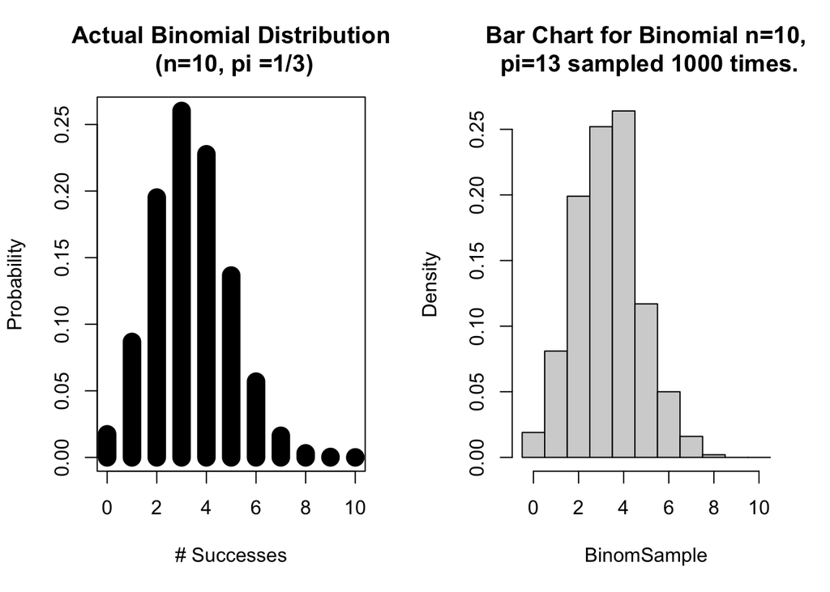

```r
par(mfrow = c(1,2))
#Plot the values from the table (the type = h is a histogram)
plot(X, Y, type = 'h',  main='Actual Binomial Distribution\n (n=10, pi =1/3)',
     ylab='Probability',
     xlab ='# Successes',
     lwd=15)
#Look at the histogram from the sample
hist(BinomSample, breaks = seq(0, 11, 1)-0.5, freq=FALSE,main= 'Bar Chart for Binomial n=10,\n pi=13 sampled 1000 times.')
```

#### Other Discrete Distributions

Similar to the binomial, other discrete distributions work the same with with ‘d’, ‘p’, ‘q’, and ‘r’. We have talked about the Poisson in class but there are other built in distributions as well. *Use the help function to see what parameters are needed for each function*.

1. **Binomial**
- Used for, X = Number of success in n trials with pi prob of success
- Possible Values 0,…,n
- `_binom()` where _ is d,p,q, r
2. **Poisson**
- Used for, X = Count occurrences in a fixed time or spacial interval under certain conditions
- Possible Values 0 to $\infty$
- `_pois()` where _ is d,p,q, r
3. **Multinomial**
- `_multinom()` where _ is d,p,q, r
4. **Geometric**
- `_geom()` where _ is d,p,q, r
5. **Negative Binomial**
- `_nbinom()` where _ is d,p,q, r
6. **Hyper Geometric**
- `_hyper()` where _ is d,p,q, r

#### Exponential Distributions

Similarly to the discrete distributions, we have the similar logic for the exponential except now ‘d’ is the continuous density function and can be plotted over an interval.

Here we use the `curve()` function to plot the exponential pdf for several different lambdas (denoted ‘rate’ in the code.)

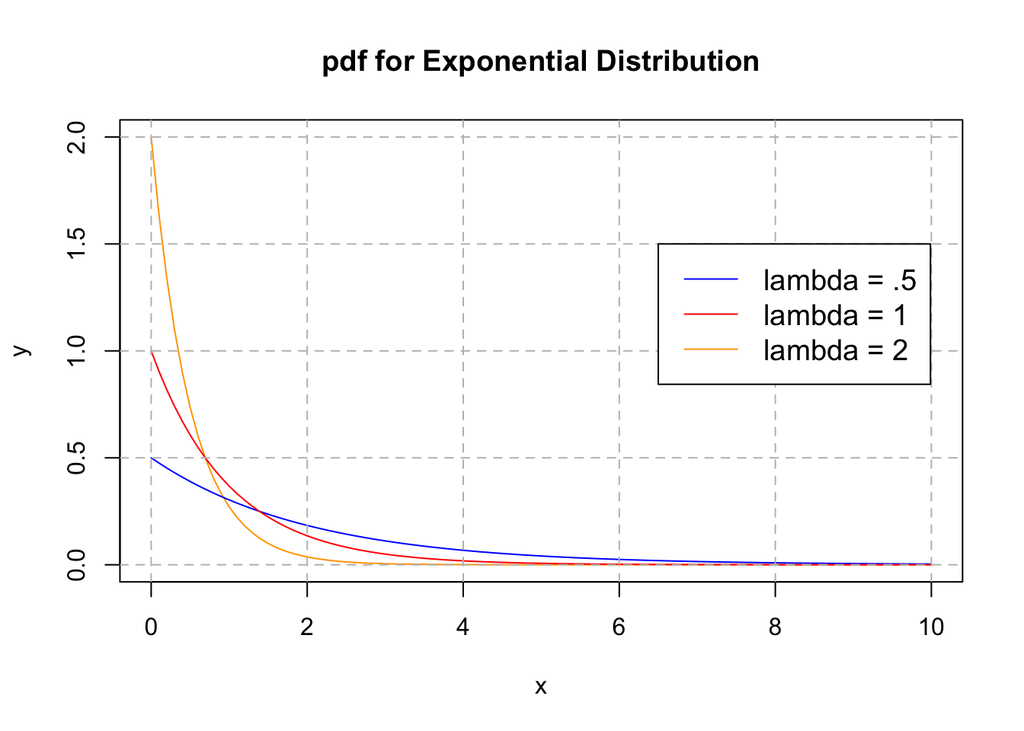

```r
#plot PDF curves
#Plots first curve for lambda =2
curve(dexp(x, rate = 2), from=0, to=10, col='orange',ylab='y', main ='pdf for Exponential Distribution')

#adds more curves for additional lambdas (add = TRUE ads to the plot instead of starting a new one)
curve(dexp(x, rate = .5), from=0, to=10, col='blue', add= TRUE)
curve(dexp(x, rate = 1), from=0, to=10, col='red', add=TRUE)

#Adds a grid for reference
grid(nx = NULL, ny = NULL, lty = 2, col = "gray", lwd = 1)

#add legend
legend(6.5, 1.5, legend=c("lambda = .5", "lambda = 1", "lambda = 2"),
       col=c("blue", "red", "orange"), lty=1, cex=1.2)
```

Note how the shape changes as lambda increases/decreases.

Similarly you could plot the CDF.

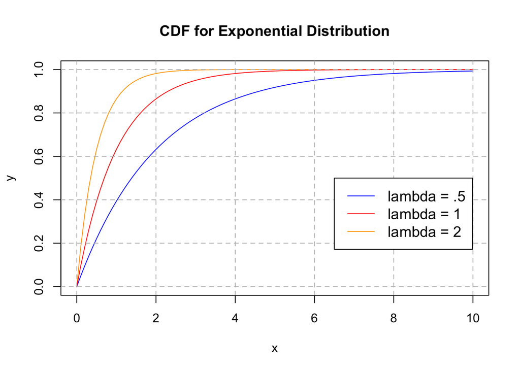

```r
#plot PDF curves
#Plots first curve for lambda =2
curve(pexp(x, rate = 2), from=0, to=10, col='orange',ylab='y', main ='CDF for Exponential Distribution')

#adds more curves for additional lambdas (add = TRUE ads to the plot instead of starting a new one)
curve(pexp(x, rate = .5), from=0, to=10, col='blue', add= TRUE)
curve(pexp(x, rate = 1), from=0, to=10, col='red', add=TRUE)

#Adds a grid for reference
grid(nx = NULL, ny = NULL, lty = 2, col = "gray", lwd = 1)

#add legend
legend(6.5, .5, legend=c("lambda = .5", "lambda = 1", "lambda = 2"),
       col=c("blue", "red", "orange"), lty=1, cex=1.2)
```

Looking at the graph above how would you identify the 50th percentile?

How is the graph of the CDF related to the pdf?

You can also create a histogram of sample data and then overlay a distribution - it should match pretty close if you sample enough.

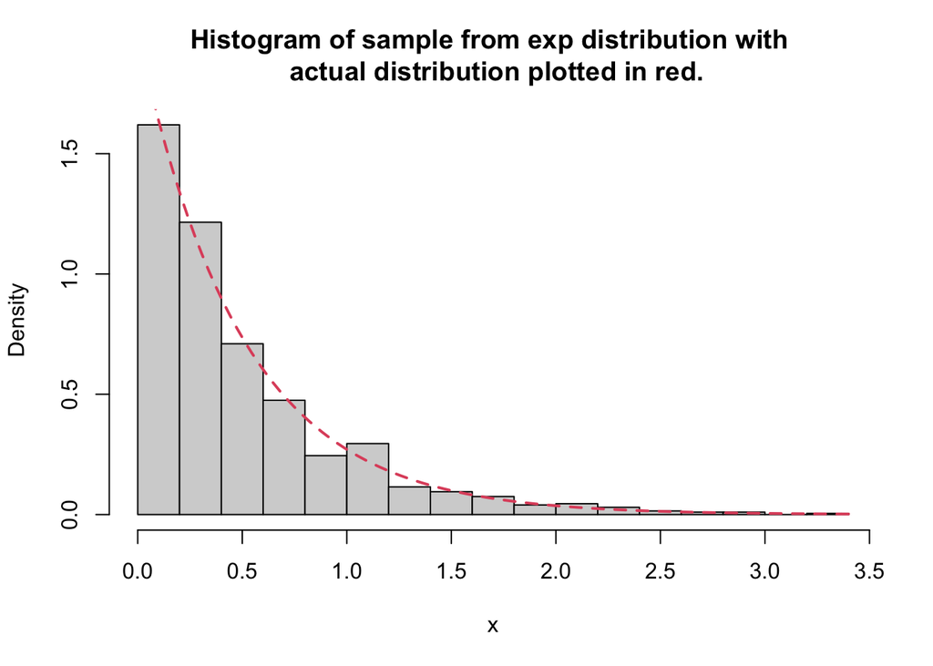

```r
#Sample 1000 times for lambda =2
z <- rexp(1000,rate = 2)
# Make a histogram!
hist(z, prob = TRUE, breaks=20, main='Histogram of sample from exp distribution with \n actual distribution plotted in red.', xlab='x')
#Overlay the actual distribution
curve(dexp(x, rate = 2), from=0, col = 2, lty = 2, lwd = 2, add = TRUE)
```

These should be pretty close because the sample data is *generated from* the distribution plotted. In general this will not be the case. You would create a histogram, decide what *type* of distribution makes sense, and then *choose* the parameter to match it as close as possible. There are also algorithms to choose the best parameter as well.

You can also use the `pexp` function to calculate probabilities of ranges, this is equivalent to integrals of `dexp`.

Suppose we have an exponential distribution with $\lambda =2$ and we want the probability that the variable is between 0.5 and 3. We know from class that this can be evaluated by:

$$P(0.5<X<3) = P(X<3)-P(X<.5)=F(3)-F(.5)=\int_.5^32e^{-2x}dx=-e^{-6}-\left(-e^{-1}\right)$$

Method 1 Integrate `dexp`:

```r
#Take the integral of dexp from 0.5 to 3

# Fist define the function and store it as the object f
f<-function(x) dexp(x,rate=2)

#then integrate the function (you can use Inf in the range!)
integrate(f, 0.5, 3)
```

```
## 0.3654007 with absolute error < 4.1e-15
```

Method 2 Use `pexp` (remember pexp is the built in function for the cdf or F):

```r
#Take the integral of dexp from 0.5 to 3
pexp(3, 2)-pexp(0.5,2)
```

```
## [1] 0.3654007
```

Method 3 Use the known values:

```r
#The exponential e^x is denoted exp(x)
-exp(-6)-(-exp(-1))
```

```
## [1] 0.3654007
```

These produce the same answer as expected.

#### Normal Distributions

Everything we just did for exponential also applies to how normal distributions work in R. You can also use the `curve()` function like we showed in the exponential case. See the bonus content for other ways of plotting.

[figure not shown]

```r
#plot PDF curves
#Plots first curve
curve(dnorm(x, mean = 2, sd=.5), from=-2, to=10, col='blue',ylab='y', main ='density for Normal Distribution')

#adds more curves for additional parameter combinations (add = TRUE ads to the plot instead of starting a new one)
curve(dnorm(x, mean = 2, sd=1), from=-2, to=10, col='orange', add= TRUE)
curve(dnorm(x, mean = 4, sd=1), from=-2, to=10, col='red', add=TRUE)

#Adds a grid for reference
grid(nx = NULL, ny = NULL, lty = 2, col = "gray", lwd = 1)

#add legend
legend(5, 0.8, legend=c("mu = 2, sigma=1", "mu = 2, sigma=.5", "mu = 4, sigma=1"),
       col=c("blue", "orange", "red"), lty=1, cex=1.2)
```

What happens when $\sigma$ gets smaller/larger? What happens when $\mu$ gets smaller/larger?

We can get z scores for normal random variable using the `qnorm` function

```r
#Z scores are all standard normal so mean =0, sd=1
#This is the 25th percentile or the value where you would have accumulated 25% of your distribution.
qnorm(.25, mean=0, sd=1)
```

```
## [1] -0.6744898
```

```r
#0 and 1 are the defaults too so you can just ignore them

qnorm(.25)
```

```
## [1] -0.6744898
```

Since the standard normal is symmetric the z score for .75 should be the same as the 25th percentile with the opposite sign. Lets check that:

```r
#Z score for .75
qnorm(.75)
```

```
## [1] 0.6744898
```

Lets plot qnorm and pnorm to see that they are inverse functions.

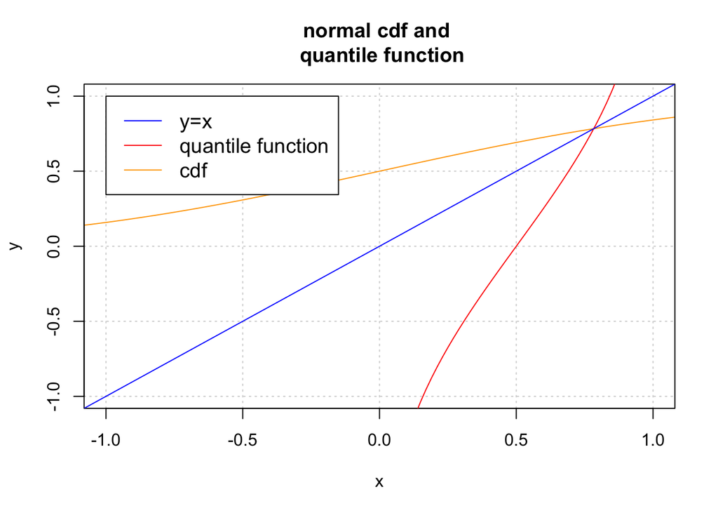

```r
x <- seq(-10,10,length.out=1000)

#evaluate the exponential for different rates on the sequence of values
y  <- pnorm(x)
y2 <- qnorm(x)
y3 <- x

#type = "l" is a line plot. Check out ?plot to see other options
#use the plot function. To add additional line plots use the lines function after the initial plot. If you have three plot lines you'll get three plots instead of all three on the same plot.

plot(x, y, type="l", col='orange', main= 'normal cdf and \n quantile function', ylim=c(-1,1), xlim<-c(-1,1), panel.first = grid())
lines(x[!is.na(y2)], y2[!is.na(y2)], type="l", col='red') # Use lines to add to
lines(x, y3, type="l", col='blue') # Use lines to add to

legend(-1, 1, legend=c("y=x", "quantile function", "cdf"),
       col=c("blue", "red", "orange"), lty=1, cex=1.2)
```

Note how the orange and the red curves (the cdf and the quantile function) are reflections over the blue line where y=x. This is the property for inverse functions.

#### Other Continuous Distributions

Similar to the binomial other discrete distributions work the same with with ‘d’, ‘p’, ‘q’, and ‘r’. We have talked about the Poisson in class but there are other built in distributions as well. *Use the help function to see what parameters are needed for each function*.

## Problems

### Problem 1

In this problem you will use some sample data and estimate what the underlying distribution is based on properties of the sample. This is a fundamental concept in statistics and there are many advanced ways to answer these kinds of problems. However for the purpose of this problem, you will just use a histogram and what you know of the families of distributions we have discussed to estimate/make an educated guess what the family and parameters are.

#### 1. Import Data

Adjust your path as necessary. The data set contains a single column of data which represent temperature measurements.

```r
DailyTemp = read.csv('DailyTemp.csv',fileEncoding="UTF-8-BOM")
attach(DailyTemp)
```

#### 2. Create a histogram

**Create a histogram of the temperature values on the density scale, select the bins so that the shape of the distribution is highlighted. Show a list of the boundary values of your bins.**

```r
# Use to calculate the bin widths or bin numbers
dim(DailyTemp) #use the rule of thumb
```

```
## [1] 4000    1
```

```r
sqrt(4000) #there are 4000 rows and 1 column
```

```
## [1] 63.24555
```

```r
summary(temp)
```

```
##    Min. 1st Qu.  Median    Mean 3rd Qu.    Max.
##   17.64   45.07   51.62   51.80   58.64   87.72
```

```r
#calculate bin width using the formula (MAX-MIN)/#bins
(88-17)/64 #binWidth
```

```
## [1] 1.109375
```

Write a sentence describing how many bins you are going to use and what the width of those bins are.

```r
#use the seq function to display the endpoints of your bins
seq(17, 88)
```

```
##  [1] 17 18 19 20 21 22 23 24 25 26 27 28 29 30 31 32 33 34 35 36 37 38 39 40 41
## [26] 42 43 44 45 46 47 48 49 50 51 52 53 54 55 56 57 58 59 60 61 62 63 64 65 66
## [51] 67 68 69 70 71 72 73 74 75 76 77 78 79 80 81 82 83 84 85 86 87 88
```

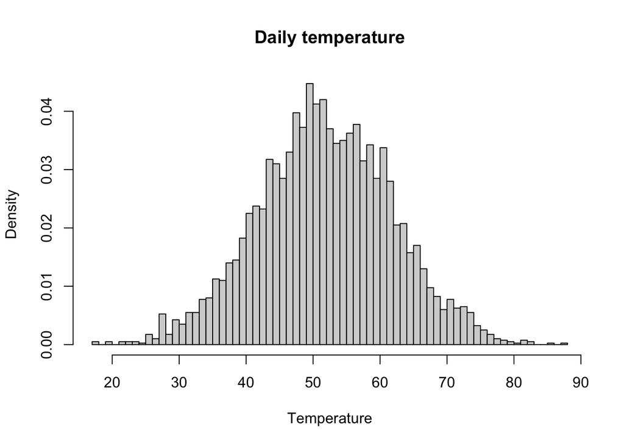

```r
# Build your histogram
hist(DailyTemp$temp, breaks = seq(17, 88, 1), freq=FALSE, xlab = "Temperature", main = 'Daily temperature')
```

#### 3. Shape

**Describe the shape of the histogram in words.**

Describe the shape in words.

- I think its shape is bell-shaped and symmetrical.

#### 4. Family

**There are sophisticated ways of testing if certain families are appropriate for a given sample and we will talk about some later in the course. For now, I want you to use what you know about the shapes of density functions to make an educated guess as to which family of distributions the data comes from. State what your guess is and why.**

Put your answer here in words.

- As stated above, the histogram is bell-shaped which usually presents a normal distribution. In a normal or “typical” distribution, points are as likely to occur on one side of the average as on the other.

#### 5. Parameters

**There are some sophisticated mathematical techniques we will explore later to determine parameters for a family to best fit some sample data that potentially came from that distribution. However, in this case there are some simple ways of coming up with what the parameters might be (think about what the names of the parameters are for the family you have chosen). Use what you know to come up with potential parameters for the underlying distribution. There are some built in functions in R that you can look up that might be helpful.**

```r
#Put in any calculations to estimate the parameters.
mean(DailyTemp$temp)
```

```
## [1] 51.80017
```

```r
sd(DailyTemp$temp)
```

```
## [1] 9.972366
```

Describe in words what the values you selected are and why.

- Since the histogram is the normal distribution, I chose the mean and standard deviation as the parameters.

#### 6. Density Plot

**Using the values calculated in 5. re-plot the histogram of the sample data but now add the curve of the density function for the distribution you decided on overlay-ed on top of the histogram.**

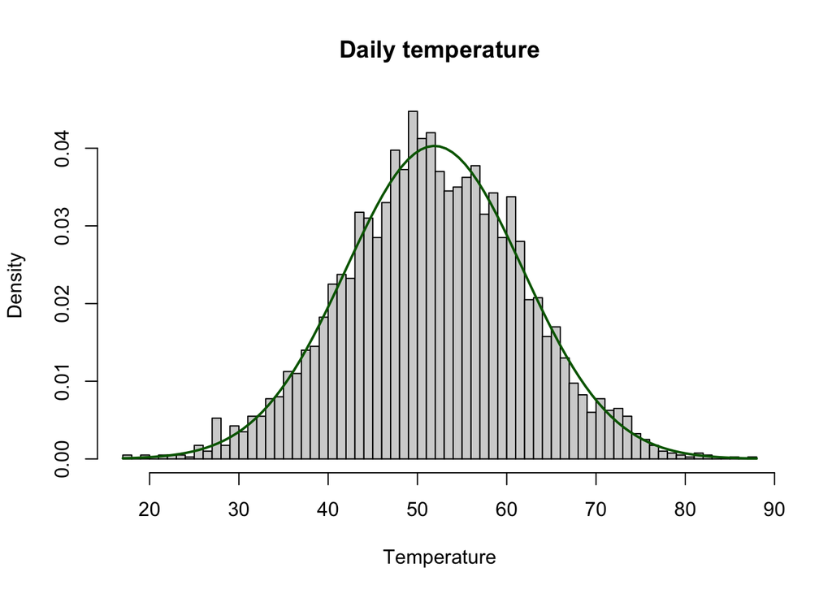

```r
#Make your histogram and the density function
hist(DailyTemp$temp, breaks = seq(17, 88, 1), freq=FALSE, xlab = "Temperature", main = 'Daily temperature')
curve(dnorm(x, mean = 51.9, sd=9.9), col='darkgreen', lwd=2, add=TRUE, yaxt="n")
```

Write a sentence or two describing if you made a good choice.

- I think i made a good choice as the curve is representing the normal distribution aka the family of the histogram very well.

### Problem 2

**In this problem you will use the built in functions to answer some questions about a Poisson Process.**

**Suppose that on average a certain store serves 15 customers per hour during their hours of operation. Assume that all assumptions of a Poisson Process hold. Use the built in functions to answer the following question.**

**When answering the questions**

- **State clearly in words the random variable you are considering, what the parameters are and how the question translates into a statement about the probability of that variable.**
- **Show the calculations in R to evaluate the probability.**
- **State in words what the final answer is.**

#### Part 1.

**What is the probability that the store swill serve between 10 and 20 customers (inclusive) in a particular 2 hour period?**

State the random variable you would use, the parameters and the probability you wish to compute.

- Random variable x = the number of customers will be served in a certain period of time

- Parameters: lambda=15

- P(10<x<20)

```r
# Put your calculations here.
#calculate P(x<10)
ppois(10, lambda = 15)
```

```
## [1] 0.1184644
```

```r
#calculate P(x>20)
ppois(20, lambda = 15, lower=FALSE)
```

```
## [1] 0.08297091
```

```r
#calculate P(10<=x<=20)
1-(ppois(10, lambda = 15) + ppois(20, lambda = 15, lower=FALSE))
```

```
## [1] 0.7985647
```

Write a sentence with the final answer.

- If on average a certain store serves 15 customers per hour during their hours of operation, the probability that the store will serve between 10 and 20 customers (inclusive) in a particular 2 hour period is 79.8%.

#### Part 2.

**At noon, the shop owner wonders how long it will be until the next customer arrives. What is the probability that the next customer will arrive in less than 3 minutes?**

State the random variable you would use, the parameters and the probability you wish to compute.

- Random variable X = how long it will be until the next customer arrives

- Parameters: lambda=15

- P(X<=3)

```r
#Put your calculation here.
ppois(3, lambda = 15)
```

```
## [1] 0.0002113785
```

Write a sentence with the final answer.

- If on an average of 1 hour the shop has 15 customers arrive, the probability of having the next customer in less than 3 minutes is 0.02%.

### Problem 3

**In this problem you will investigate two approximations of a Binomial distribution.**

**In particular we will consider the following scenario:**

**The probability that a person will develop an infection even after taking a vaccine that was supposed to prevent the infection is 0.01.**

#### 1. Binomial

**Using a binomial random variable answer the following question.**

**From a random sample of 1000 people in a community who got the vaccine, what is the probability that twelve or fewer people will be infected? State clearly what n and** $\pi$ **are, show the code for your calculation and summarize your result in a sentence.**

Describe the distribution you are going to use and what the parameters are.

- I’m going to use cumulative distribution function

```r
#Put your calculation here
# Cumulative distribution function (cdf): this cacluates the probability X <= 12.
pbinom(12,1000,0.01)
```

```
## [1] 0.7925116
```

Write a sentence with your final answer.

- From a random sample of 1000 people in a community who got the vaccine, the probability that twelve or fewer people will be infected is 79.25%.

#### 2. Poisson

**Show that the conditions necessary for the Poisson approximation of a binomial random variable hold and then use a Poisson random variable to approximate the the probability that twelve or fewer people will be infected in a random sample of 1000 people in a community who got the vaccine.**

**State clearly in words why the conditions are met and what** $\lambda$ **is for the Poisson random variable. Show your calculation for the probability and the summarize the result in a sentence or two.**

Write here why the conditions are met and what lambda is.

- The conditions are met because we have: n=1000 (>100), pi=0.01 (<=0.01), lambda=10 (<20)

- lambda=n**pi=1000**0.01=10

```r
#Do your calculations with a Poisson here.
ppois(12, lambda = 10)
```

```
## [1] 0.7915565
```

Write a sentence with your final answer.

- From a random sample of 1000 people in a community who got the vaccine, the probability that twelve or fewer people will be infected is 79.16%.

#### 3. Normal

**It is also possible to approximate a binomial random variable with a normal random variable under certain circumstances. The conditions for this are that** $n*\pi >5$ **and** $n*(1-\pi)>5$. **If these are satisfied then a normal random variable with** $\mu = n*\pi$ **and** $\sigma = \sqrt{n\pi(1-\pi)}$. **Can be used as an approximation.**

**When these conditions hold you should also use a continuity correction to account for the fact that the normal distribution is continuous and the binomial is discrete. To do this you extend your normal range by 0.5 beyond the integer values you want. So if you wanted P(X=3) you would use the range 2.5 to 3.5. If you wanted P(2<X<=5) you would use the range 2.5 to 5.5.**

**Using the same scenario as above, state clearly in words why the conditions are met and what** $\mu$ **and** $\sigma$ **are for the normal random variable. Then use this normal random variable to to approximate the the probability that twelve or fewer people will be infected in a random sample of 1000 people in a community who got the vaccine. Show your calculation for the probability using the normal random variable and the summarize the result in a sentence or two.**

State why the conditions are satisfied and state the parameters .

- The conditions are met because we have: n**pi=1000**0.01=10 (>5), n**(1-pi)=1000**(1-0.01)=990 (>5)

```r
#Put your calculations here.
pnorm(12.5, mean = 10, sd = 3.15)
```

```
## [1] 0.7863006
```

Write a sentence with your final answer.

- From a random sample of 1000 people in a community who got the vaccine, the probability that twelve or fewer people will be infected is 78.63%.

#### 4. Simulation

**In this problem you will pretend that you executed this experiment 2000 times. In other words you collect 2000 different samples of size 1000. For each of these 2000 samples you calculate the number out of 1000 infected.**

1. **Use th built in sampling function rbinom(…) to create your 2000 outcomes.**
2. **Show a Summary of the outcomes including the mean (use the summary function).**
3. **Draw a histogram of those outcomes. Use hist() and make your breaks be width of 1 starting at -.05. This will give you bars centered at each integer value. You can do this by defining breaks similar to `breaks = seq(0,Mx+1, 1)-0.5`** **where Mx is the maximum value from your sample.**
4. **Overlay the histogram with a Normal density function with the params derived in the normal approximation above.**
5. **Comment on the similarity or differences.**

```r
# Create 2000 sample outcomes of this experiment. Record the outcomes as a vector (you can call it something line SampleData)

SampleData= rbinom(2000,1000,0.01)

#Show a Summary of SampleData
summary(SampleData)
```

```
##    Min. 1st Qu.  Median    Mean 3rd Qu.    Max.
##    2.00    8.00   10.00   10.02   12.00   24.00
```

```r
#Create a variable Mx = max(SampleData)
Mx = max(SampleData)

#Plot a histogram of Sample Data use breaks equal to the formula given in the problem
hist(SampleData, breaks = seq(0,Mx+1,1)-0.5, freq=FALSE, xlab = "x", main = 'Sample Data')

#Overlay a curve of the normal random variable with the parameters derived aboe.
mean(SampleData)
```

```
## [1] 10.015
```

```r
sd(SampleData)
```

```
## [1] 3.124845
```

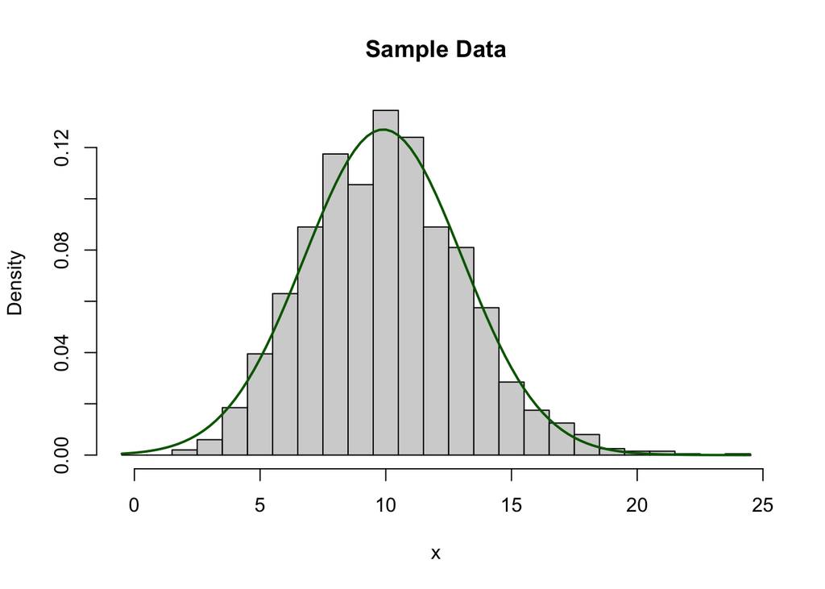

```r
curve(dnorm(x, mean = 9.9, sd=3.14), col='darkgreen', lwd=2, add=TRUE, yaxt="n")
```

Write a couple sentences to describe the result.

- Even though my values are come from the binomial distribution but the histogram still remains as the belly-shaped because It is also possible to approximate a binomial random variable with a normal random variable. In this case, we already proved in part 3-3 that all the conditions are satisfied for this to happen.

## Alternate Plotting (Bonus Content)

An alternate way is to use ggplot or plot with a very fine sequence of values.

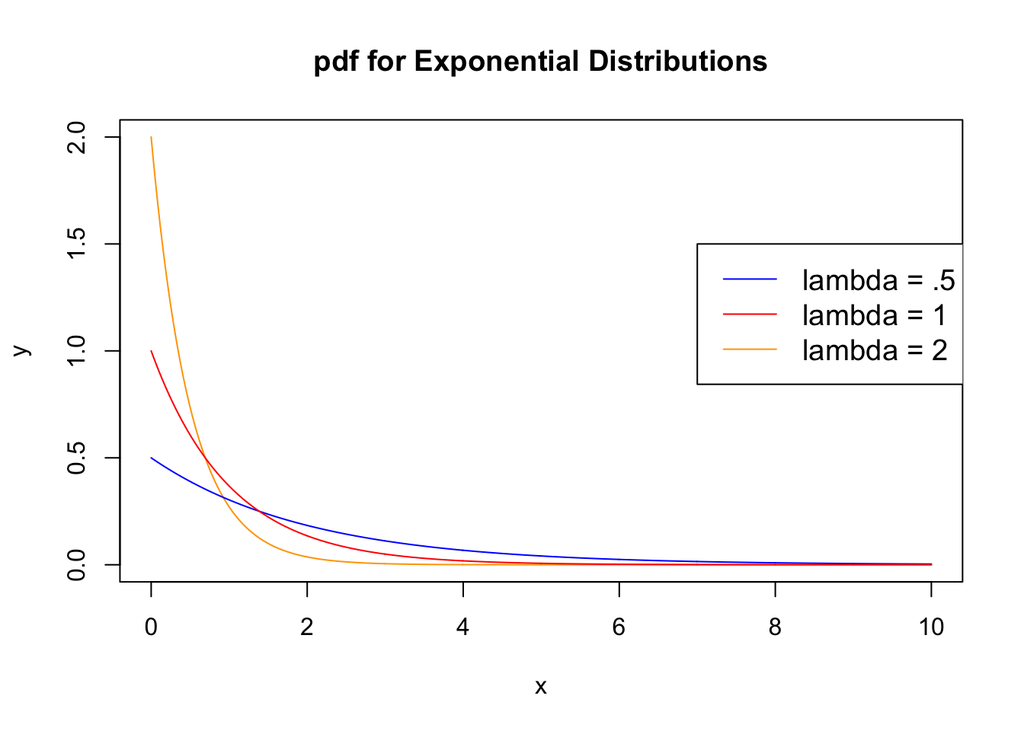

```r
#Using plot
#First define a sequence of values
x <- seq(0,10,length.out=1000)

#evaluate the exponential for different rates on the sequence of values
y <- dexp(x, rate = 2)
y2 <- dexp(x, rate = 0.5)
y3 <- dexp(x, rate = 1)

#type = "l" is a line plot. Check out ?plot to see other options
#use the plot function. To add additional line plots use the lines function after the initial plot. If you have three plot lines you'll get three plots instead of all three on the same plot.

plot(x, y, type="l", col='orange', main= 'pdf for Exponential Distributions')
lines(x, y2, type="l", col='blue') # Use lines to add to the previous plot
lines(x, y3, type="l", col='red') # Use lines to add to the previous plot
legend(7, 1.5, legend=c("lambda = .5", "lambda = 1", "lambda = 2"),
       col=c("blue", "red", "orange"), lty=1, cex=1.2)
```

Finally you could use ggplot

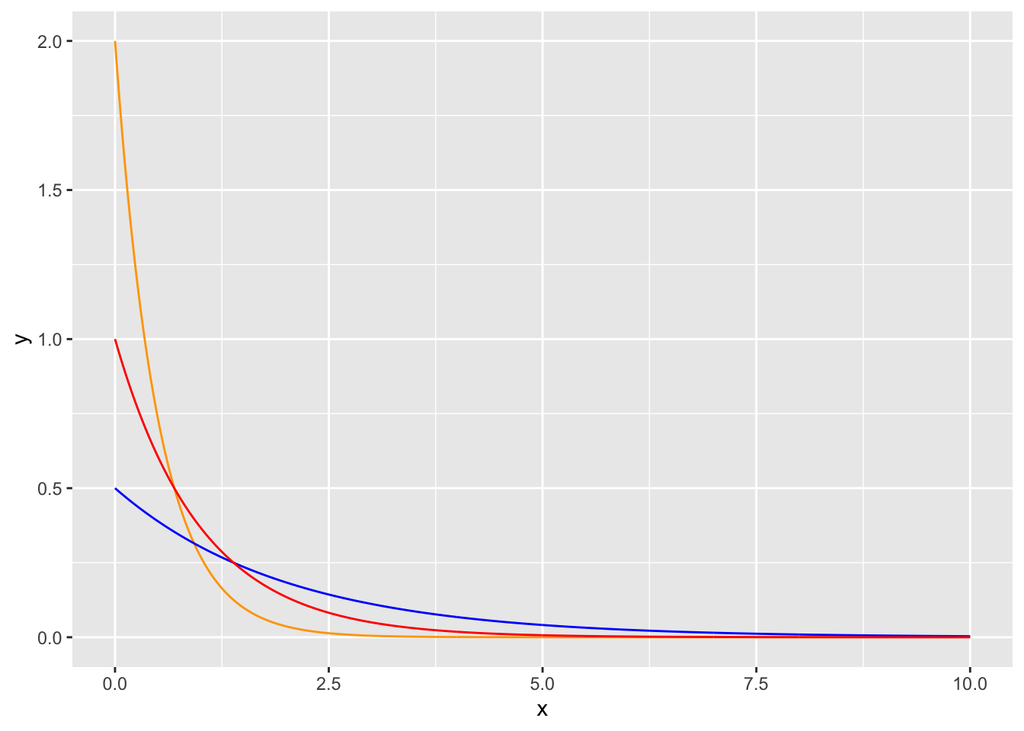

```r
#Using plot
x <- seq(0,10,length.out=1000)
y <- dexp(x, rate = 2)
y2 <- dexp(x, rate = 0.5)
y3 <- dexp(x, rate = 1)

#Put all the data in one dataframe
PlotData = data.frame(x, y, y2, y3)

ExponentialPlot <- ggplot(PlotData, aes(x)) +
    geom_line(aes(y = y), color = "orange") +
     geom_line(aes(y = y2), color = "blue") +
    geom_line(aes(y = y3), color = "red")

ExponentialPlot
```

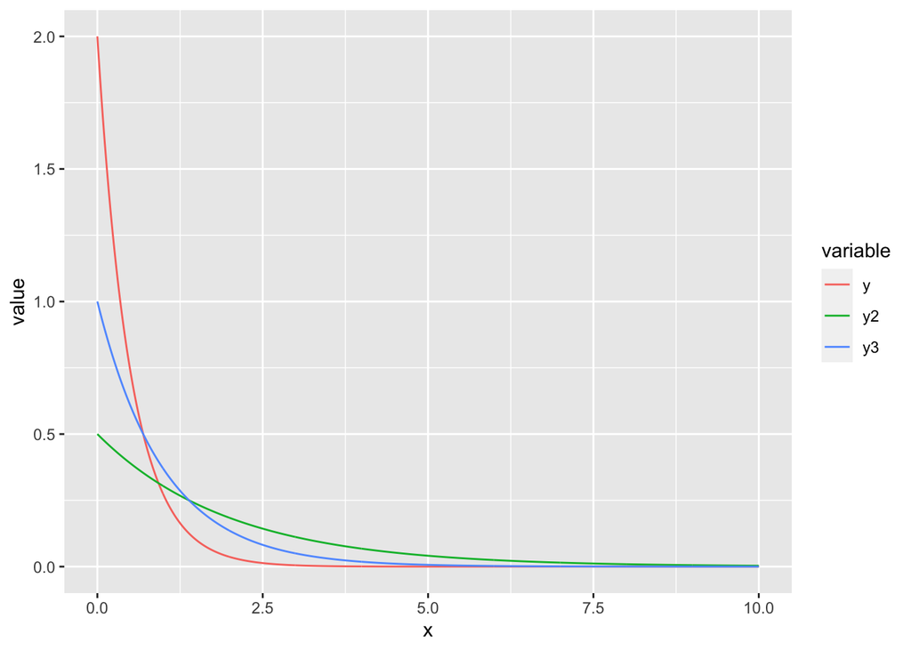

```r
#or

data_long <- melt(PlotData, id = "x")
ExponentialPlot2 <- ggplot(data_long,
               aes(x = x,
                   y = value,
                   color = variable)) +  geom_line()
ExponentialPlot2
```

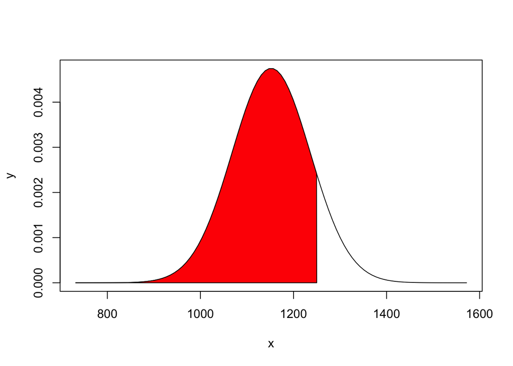

```r
# Define the Mean and Stdev
mean=1152
sd=84

# Create x and y to be plotted
# x is a sequence of numbers shifted to the mean with the width of sd.
# The sequence x includes enough values to show +/-3.5 standard deviations in the data set.
# y is a normal distribution for x
x <- seq(-5,5,length=100)*sd + mean
y <- dnorm(x,mean,sd)

# Plot x vs. y as a line graph
plot(x, y, type="l")

# Shade to the right of 1250
polygon(c( x[x<=1250], 1250,min(x)), c(y[x<=1250], 0, 0), col="red")
```

```r
# This area corresponds to the cdf at 1250
print(paste0('The shaded area is equal to ', pnorm(1250,mean,sd)))
```

```
## [1] "The shaded area is equal to 0.878327495425619"
```